# Aula 11 - Econometria de Séries Temporais

Autor

João Ricardo F. de Lima

Data de Publicação

16 de junho de 2025

# VEC - Vetorial Autorregressivo com correção de erro

Um dos pressupostos para se estimar um modelo VAR é que as variáveis sejam estacionárias. Isso significa que se essa hipótese for violada, é necessário realizar outro tipo de análise, verificando a existência de **cointegração** entre duas ou mais variáveis, isto é, se existe uma relação de longo-prazo entre elas.

Se as séries não forem estacionárias, ainda assim pode existir uma relação entre elas ao longo do tempo. Nesse caso, diz-se que as séries possuem uma tendência comum, o que permite investigar uma possível cointegração e, assim, avaliar a existência de uma relação de longo prazo entre elas.

Sejam $Y_t$, $X_t$ e $Z_t$ três séries temporais e a seguinte relação de interesse:

$$Y_t=\alpha+\beta X_t+ \gamma Z_t + \epsilon_t$$

Neste caso tem que se considerar as seguintes possibilidades:

1. Se $Y_t$, $X_t$ e $Z_t$ são estacionárias, estima-se a equação acima em nível
2. Se $Y_t$, $X_t$ e $Z_t$ são não estacionárias, tem-se outras possibilidades:

Se $Y_t$, $X_t$ e $Z_t$ são não estacionárias mas co-integradas, deve-se estimar um Modelo de Correçao de Erro (MCE) na forma uni ou multivariada dado por

$$\Delta Y_t=\alpha+\beta \Delta X_t+ \gamma \Delta Z_t +\lambda \hat{\epsilon}_{t-1}+u_t$$

em que $\hat{\epsilon}_{t-1}$ são os resíduos da primeira equação mostrada.

Se $Y_t$, $X_t$ e $Z_t$ são não estacionárias e não co-integradas, deve-se ajustar a primeira equação em primeiras diferenças, ou seja,

$$\Delta Y_t=\alpha+\beta \Delta X_t+ \gamma \Delta Z_t + v_t$$

## Co-integração - Relações de Equilíbrio de Longo Prazo

As séries $Y_{1t}, Y_{2t}, Y_{3t}, \dots,Y_{kt}$ são **cointegradas de ordem (d, b)** se todas forem integradas de ordem $d$, ou seja, $I(d)$, e existir uma combinação linear dessas variáveis que seja integrada de ordem $(d-b)$, com $0 \leq b \leq d$.

Essa combinação linear é dada por:

$$Z_t = a_1Y_{1t} + a_2Y_{2t} + a_3Y_{3t} + \dots + a_kY_{kt}$$

O vetor $a = [a_1 \quad a_2 \quad a_3 \quad \dots \quad a_k]'$ é chamado de **vetor de cointegração**.

O caso de maior interesse na análise econômica ocorre quando essa combinação linear é estacionária, ou seja, $I(0)$.

Considere $Y_t \sim I(1)$, $X_t \sim I(1)$ e $Z_t \sim I(1)$, com a seguinte relação de equilíbrio:

$$Y_t = \beta_0 + \beta_1 X_t + \beta_2 Z_t$$

Essa relação estará em **equilíbrio de longo prazo** se:

$$0 = Y_t - \beta_0 - \beta_1 X_t - \beta_2 Z_t$$

Ou seja, para que o equilíbrio tenha significado econômico, o resíduo dessa equação deve ser estacionário.

Assim, se:

$$\epsilon_t = Y_t - \beta_0 - \beta_1 X_t - \beta_2 Z_t \sim I(0)$$

então as três séries são cointegradas, com vetor de cointegração dado por:

$$\beta = [1 \quad -\beta_0 \quad -\beta_1 \quad -\beta_2]'$$

## Vetores de Cointegração

Os vetores de cointegração não são únicos — podem existir várias combinações lineares que tornam as séries estacionárias. O número máximo de vetores de cointegração depende do número de variáveis envolvidas:

- **Caso com 2 variáveis**: existe no máximo **1 vetor de cointegração**, representando uma única relação de equilíbrio de longo prazo;
- **Caso com $k$ variáveis**: podem existir até **$k - 1$ vetores de cointegração linearmente independentes**.

## Rank de Co-integração

O rank de CI (r) é o número de vetores de CI linearmente independentes. Para k variáveis de mesma ordem de integração e co-integradas, $1 \le r \le k-1$.

## Testes de Co-Integração - Caso Multivariado

Para se testar co-integração no caso Multivariado, suponha K variáveis todas integradas de mesma ordem I(1). Sendo as variáveis todas I(1), a existência de combinações lineares I(0) entre elas indica que estas variáveis são co-integradas. Estas combinações lineares governam o comportamento de equilíbrio de longo prazo. Em geral, existem $r\le K-1$ combinações lineares independentes que são as relações de CI e é necessário encontrar o valor de r;

Se r=K as variáveis são I(0). Se r=0, não existe relação de longo prazo entre as variáveis. Se $1 \le r \le k-1$, existem de 1 até k-1 vetores de co-integração e é necessário definir o valor de r.

A metodologia para se determinar o número de vetores de CI e estimar as relações de CI é baseada na estimação de um **Modelo Vetorial Autorregressivo** conhecido como modelo VAR, que foi desenvolvida por Johansen.

### Teste de Co-Integração de Johansen

Considere um VAR(2) com k variáveis, todas possuindo raiz unitária:

$$Y_t=\alpha+\theta_1Y_{t-1}+\theta_2Y_{t-2}+\epsilon_t$$

É possível subtrair $Y_{t-1}$ dos dois lados nesta equação e rearranjar os termos para obter:

$$\Delta Y_t=\alpha+(\theta_1+\theta_2-I)Y_{t-1}-\theta_2 \Delta y_{t-1}+\epsilon_t$$

com um pouco mais de álgebra é possível reescrever um VAR(p) com k variáveis como um VEC (VAR Reparametrizado) da forma

$$\Delta Y_t=\alpha+\Pi Y_{t-1}+ \sum_{i=1}^{p-1}\Gamma_i\Delta y_{t-i}+\epsilon_t$$

em que

$$\Pi=\sum_{j=1}^{p}\theta_j-I$$

e

$$\Gamma_i=- \sum_{j=i+1}^{p}\theta_j$$

$\Pi$ é a matriz dos coeficientes das relações de cointegração; $\Gamma$ é a matriz dos coeficientes da variável $Y$ diferenciada defasadas.

A diferença do VEC para o VAR é o termo de correção de erro $\Pi Y_{t-1}$. Engle e Granger (1987) mostraram que $\Pi$ tem rank r, $0 \le r <K$, em que r é o número de vetores de cointegração linearmente independentes entre os elementos do vetor $Y_t$. Assim, não se pode simplesmente estimar um VAR em $\Delta Y_t$ quando existe relações de cointegração pois se estaria omitindo $\Pi Y_{t-1}$. Se não existem relações de cointegração entre os elementos de $Y_t$, o rank de $\Pi$ é 0 e o termo $\Pi Y_{t-1}$ desaparece.

Se rank $(\Pi)=r<k$, pode-se mostrar que existem matrizes $\psi_{kxr}$ e $\beta_{kxr}$ tais que

$$\Pi_{KxK}=\psi_{kxr} \beta_{rxk}'$$

Substituindo na equação do VAR reparametrizado, obtém-se

$$\Delta Y_t=\alpha+ \psi \beta'Y_{t-1}+\sum_{i=1}^{p-1}\Gamma_i\Delta y_{t-i}+\epsilon_t$$

que é denominado de **Modelo de Correção de Erro Vetorial (VEC)**. O VEC, então, é um VAR (reparametrizado) com as restrições de co-integração entre as variáveis.

Tem-se que

1. $\beta'Y_{t-1}$= são as ``r’’ relações de cointegração que definem o equilíbrio de longo prazo ente as variáveis;
2. $\psi$=matriz de coeficientes de ajustamento de longo prazo;
3. $\Gamma_i$=matrizes de coeficientes que definem a dinâmica de curto prazo;

O procedimento de Johansen consiste em testar o número de raízes características diferentes de zero na matriz $\Pi$ que corresponde ao número de relações e vetores de cointegração entre as variáveis.

São utilizados dois testes:

1. **Teste do Traço**:

$H_0:r \le r_0$

$H_1:r_0<r \le k$

Estatística de teste:

$$\lambda_{traco}=-T \sum_{i=r_0+1}^{k} ln(1-\hat{\lambda_i})$$

2. **Teste da Raiz Característica Máxima**:

$H_0:r \le r_0$

$H_1:r=r_0+1$

Estatística de teste:

$$\lambda_{max}=-T ln(1-\hat{\lambda_{r_0+1}})$$

Os testes são realizados em sequencia até que a hipótese nula não seja rejeitada.

# Exemplo 1

Considere 3 processos simulados, sendo dois AR(1) e um passeio aleatório.

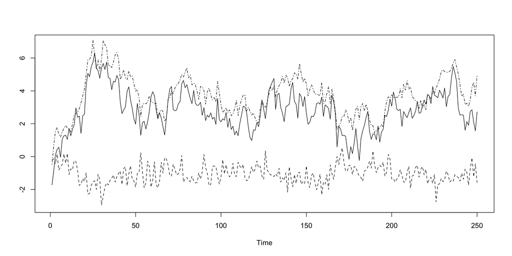

```r
set.seed(9)

e1 <- rnorm(250,0,0.5)
e2 <- rnorm(250,0,0.5)
e3 <- rnorm(250,0,0.5)

u1.ar1 <- arima.sim(model = list(ar=0.75), innov = e1, n = 250)
u2.ar1 <- arima.sim(model = list(ar=0.3), innov = e2, n = 250)

y3 <- cumsum(e3)
y1 <- 0.8*y3 + u1.ar1
y2 <- -0.3*y3 + u2.ar1


y.mat <- data.frame(y1,y2,y3)

# Figura 8.8
plot.ts(y1, lty = 1, ylim = c(-3,7), ylab = "")
lines(y2, lty = 2)
lines(y3, lty = 4)
```

A função do R ca.jo() estima as matrizes $\alpha$ e $\beta$, além das estatísticas de teste para os dois métodos.

A estimação do VEC é feita em duas etapas, na primeira se estima, por máxima verossimilhança, as relações de cointegração, e em seguida, com mínimos quadrados, os coeficientes dos termos determinísticos e de defasagem.

Nos resultados, $r=0$ equivale a hipótese de não existência de relações de cointegração, enquanto $r \leq i$ equivale à de i ou menos relações de cointegração.

Abaixo, a saída do teste do máximo autovalor:

```r
library(vars)
vecm <- ca.jo(y.mat, type = c("eigen"), ecdet = "const")

jo.results <- summary(vecm)
jo.results
```

```
######################
# Johansen-Procedure #
######################

Test type: maximal eigenvalue statistic (lambda max) , without linear trend and constant in cointegration

Eigenvalues (lambda):
[1] 3.357938e-01 1.410541e-01 4.949758e-02 1.216835e-18

Values of teststatistic and critical values of test:

           test 10pct  5pct  1pct
r <= 2 |  12.59  7.52  9.24 12.97
r <= 1 |  37.71 13.75 15.67 20.20
r = 0  | 101.47 19.77 22.00 26.81

Eigenvectors, normalised to first column:
(These are the cointegration relations)

             y1.l2       y2.l2      y3.l2   constant
y1.l2     1.000000  1.00000000  1.0000000   1.000000
y2.l2    23.739744 -0.01440361  0.9326373   0.508324
y3.l2     5.521199 -0.83720628 -6.9751085  -4.804581
constant  1.916051  0.31478225 25.5249365 -11.754289

Weights W:
(This is the loading matrix)

            y1.l2       y2.l2        y3.l2      constant
y1.d -0.002543326 -0.28362568  0.013102253 -6.443480e-18
y2.d -0.037142149 -0.01269080 -0.004450528 -9.771012e-18
y3.d -0.003204754  0.04075187  0.013609744  1.381277e-18
```

```r
vect <- ca.jo(y.mat, type = c("trace"), ecdet = "const")

jo.results <- summary(vect)
jo.results
```

```
######################
# Johansen-Procedure #
######################

Test type: trace statistic , without linear trend and constant in cointegration

Eigenvalues (lambda):
[1] 3.357938e-01 1.410541e-01 4.949758e-02 1.216835e-18

Values of teststatistic and critical values of test:

           test 10pct  5pct  1pct
r <= 2 |  12.59  7.52  9.24 12.97
r <= 1 |  50.30 17.85 19.96 24.60
r = 0  | 151.77 32.00 34.91 41.07

Eigenvectors, normalised to first column:
(These are the cointegration relations)

             y1.l2       y2.l2      y3.l2   constant
y1.l2     1.000000  1.00000000  1.0000000   1.000000
y2.l2    23.739744 -0.01440361  0.9326373   0.508324
y3.l2     5.521199 -0.83720628 -6.9751085  -4.804581
constant  1.916051  0.31478225 25.5249365 -11.754289

Weights W:
(This is the loading matrix)

            y1.l2       y2.l2        y3.l2      constant
y1.d -0.002543326 -0.28362568  0.013102253 -6.443480e-18
y2.d -0.037142149 -0.01269080 -0.004450528 -9.771012e-18
y3.d -0.003204754  0.04075187  0.013609744  1.381277e-18
```

Observe que as estatísticas de teste rejeitam as duas hipóteses nulas iniciais ($r=0$ e $r \leq 1$) a 1% de significância. Como se tem três variáveis, haverá no máximo 2 vetores de cointegração.

Resultado semelhante foi encontrado na estatística do traço.

Por padrão, a saída mostra tambem os vetores de cointegração normalizados para a primeira variável, uma transformação proposta por Johansen.

Para se estimar os demais coeficientes do modelo se utiliza a função cajorls() com base na quantidade de relações de cointegração.

```r
vecm.r2 <- cajorls(vecm, r = 2)
vecm.r2
```

```
$rlm

Call:
lm(formula = substitute(form1), data = data.mat)

Coefficients:
        y1.d      y2.d      y3.d
ect1    -0.28617  -0.04983   0.03755
ect2    -0.05629  -0.88156  -0.07667
y1.dl1  -0.22437  -0.10328   0.07510
y2.dl1   0.08227  -0.80306   0.01229
y3.dl1   0.07289  -0.05364  -0.16650


$beta
               ect1       ect2
y1.l2     1.0000000 0.00000000
y2.l2     0.0000000 1.00000000
y3.l2    -0.8333508 0.26767559
constant  0.3157532 0.06741008
```

A saída da função retorna não só os vetores com as relações de longo prazo (beta), assim como a matriz de coeficientes do modelo (rlm) e os termos de ajuste (ect), componentes de alpha.

Na seção correspondente aos vetores de cointegração (beta), se tem duas colunas, cada uma com um vetor de cointegração. Como estão normalizados, pode-se facilmente encontrar a contrapartida com os coeficientes do processo gerador.

# Exemplo 2 - Análise de Preços de Boi Gordo

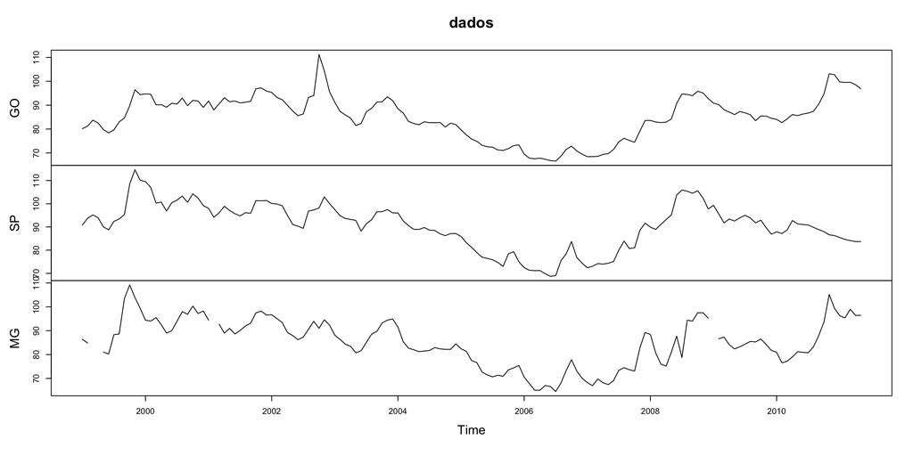

```r
#Direcionado o R para o Diretorio a ser trabalhado
setwd('/Users/jricardofl/Dropbox/tempecon/facape/econometria2')

#Limpa o Ambiente Global
rm(list=ls())

#Inicio do Script
#Pacotes a serem utilizados
#library(BMR)
library(vars)
library(urca)
library(forecast)
library(zoo)
library(xts)
library(lmtest)
library(imputeTS)
library(ggfortify)
library(aod)

#library(devtools)
#install_github("kthohr/BMR")

#Leitura dos Dados
#Boi Gordo em Goias, Sao Paulo e Minas Gerais
dados <- ts(read.csv2('boigordo.csv', header = T,
                      sep=',', dec='.')[,-1],
            start=c(1999,01), freq=12)
dates <- seq(as.Date('1999-01-01'), as.Date('2011-05-01'),
             by='1 month')
#gtsplot(dados, dates=dates)
plot(dados)
```

Resolução do problema de dados faltando com Filtro de Kalman para a série de preços de MG

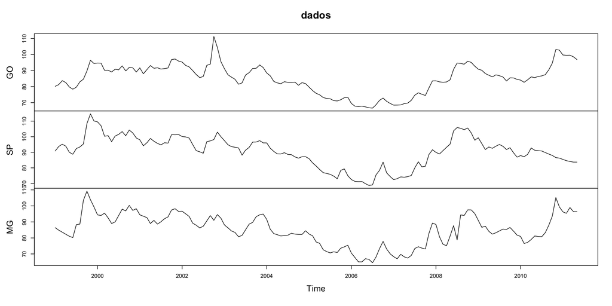

```r
dados <-na_kalman(dados)
plot(dados)
```

```r
#Analise da Estacionariedade das series
#Teste de Raiz Unitaria na Serie
#Verificacao da Estacionariedade das series
#Teste de raiz unitaria DF-GLS
#Definicao do numero maximo de lags
print(12*(length(dados)/100)^(1/4))
```

```
[1] 17.4485
```

```r
#Estatistica de Teste DFGLS para Pre?o de Goias
goT.dfgls <- ur.ers(dados[,1], type = c("DF-GLS"),
                      model = c("trend"),
                      lag.max = 12)
summary(goT.dfgls)
```

```
###############################################
# Elliot, Rothenberg and Stock Unit Root Test #
###############################################

Test of type DF-GLS
detrending of series with intercept and trend


Call:
lm(formula = dfgls.form, data = data.dfgls)

Residuals:
    Min      1Q  Median      3Q     Max
-7.3631 -1.2345 -0.3764  0.7937 16.1887

Coefficients:
              Estimate Std. Error t value Pr(>|t|)
yd.lag        -0.04992    0.02700  -1.849   0.0669 .
yd.diff.lag1   0.14331    0.08939   1.603   0.1114
yd.diff.lag2   0.04906    0.08953   0.548   0.5847
yd.diff.lag3  -0.03828    0.08795  -0.435   0.6642
yd.diff.lag4  -0.11580    0.08739  -1.325   0.1876
yd.diff.lag5   0.05866    0.08801   0.667   0.5063
yd.diff.lag6  -0.03319    0.08789  -0.378   0.7063
yd.diff.lag7  -0.03233    0.08995  -0.359   0.7199
yd.diff.lag8  -0.06808    0.09025  -0.754   0.4521
yd.diff.lag9   0.11186    0.08874   1.261   0.2098
yd.diff.lag10  0.02377    0.08903   0.267   0.7899
yd.diff.lag11  0.13872    0.08842   1.569   0.1192
yd.diff.lag12  0.15824    0.08905   1.777   0.0781 .
---
Signif. codes:  0 '***' 0.001 '**' 0.01 '*' 0.05 '.' 0.1 ' ' 1

Residual standard error: 2.7 on 123 degrees of freedom
Multiple R-squared:  0.1623,    Adjusted R-squared:  0.07379
F-statistic: 1.833 on 13 and 123 DF,  p-value: 0.04495


Value of test-statistic is: -1.8489

Critical values of DF-GLS are:
                 1pct  5pct 10pct
critical values -3.46 -2.93 -2.64
```

```r
#Estatistica de Teste DFGLS para Pre?o de S?o Paulo
spT.dfgls <- ur.ers(dados[,2], type = c("DF-GLS"),
                    model = c("trend"),
                    lag.max = 12)
summary(spT.dfgls)
```

```
###############################################
# Elliot, Rothenberg and Stock Unit Root Test #
###############################################

Test of type DF-GLS
detrending of series with intercept and trend


Call:
lm(formula = dfgls.form, data = data.dfgls)

Residuals:
    Min      1Q  Median      3Q     Max
-6.9435 -1.4622 -0.3128  1.1330  8.2474

Coefficients:
               Estimate Std. Error t value Pr(>|t|)
yd.lag        -0.071904   0.026857  -2.677  0.00844 **
yd.diff.lag1   0.117644   0.087763   1.340  0.18256
yd.diff.lag2   0.008616   0.086639   0.099  0.92095
yd.diff.lag3   0.023879   0.085385   0.280  0.78021
yd.diff.lag4  -0.008848   0.080527  -0.110  0.91268
yd.diff.lag5  -0.036817   0.080509  -0.457  0.64826
yd.diff.lag6   0.050848   0.080050   0.635  0.52648
yd.diff.lag7  -0.062822   0.079753  -0.788  0.43238
yd.diff.lag8  -0.016640   0.079005  -0.211  0.83353
yd.diff.lag9   0.097461   0.078723   1.238  0.21807
yd.diff.lag10  0.139064   0.079255   1.755  0.08181 .
yd.diff.lag11  0.133718   0.079273   1.687  0.09417 .
yd.diff.lag12  0.105848   0.079289   1.335  0.18435
---
Signif. codes:  0 '***' 0.001 '**' 0.01 '*' 0.05 '.' 0.1 ' ' 1

Residual standard error: 2.534 on 123 degrees of freedom
Multiple R-squared:  0.174, Adjusted R-squared:  0.08674
F-statistic: 1.994 on 13 and 123 DF,  p-value: 0.02649


Value of test-statistic is: -2.6773

Critical values of DF-GLS are:
                 1pct  5pct 10pct
critical values -3.46 -2.93 -2.64
```

```r
#Estatistica de Teste DFGLS para Pre?o de Minas Gerais
mgT.dfgls <- ur.ers(dados[,3], type = c("DF-GLS"),
                    model = c("trend"),
                    lag.max = 13)
summary(mgT.dfgls)
```

```
###############################################
# Elliot, Rothenberg and Stock Unit Root Test #
###############################################

Test of type DF-GLS
detrending of series with intercept and trend


Call:
lm(formula = dfgls.form, data = data.dfgls)

Residuals:
    Min      1Q  Median      3Q     Max
-7.3119 -1.8387 -0.3214  1.5682 15.3409

Coefficients:
              Estimate Std. Error t value Pr(>|t|)
yd.lag        -0.05996    0.03493  -1.716   0.0886 .
yd.diff.lag1   0.05233    0.09147   0.572   0.5683
yd.diff.lag2   0.09934    0.09167   1.084   0.2807
yd.diff.lag3  -0.13780    0.09222  -1.494   0.1377
yd.diff.lag4  -0.02455    0.09183  -0.267   0.7896
yd.diff.lag5   0.08845    0.09095   0.972   0.3328
yd.diff.lag6  -0.01654    0.08574  -0.193   0.8473
yd.diff.lag7  -0.11985    0.08768  -1.367   0.1742
yd.diff.lag8  -0.15803    0.08635  -1.830   0.0697 .
yd.diff.lag9   0.09769    0.08756   1.116   0.2668
yd.diff.lag10  0.20229    0.08694   2.327   0.0216 *
yd.diff.lag11  0.01388    0.08682   0.160   0.8733
yd.diff.lag12  0.05187    0.08654   0.599   0.5501
yd.diff.lag13  0.20400    0.08662   2.355   0.0201 *
---
Signif. codes:  0 '***' 0.001 '**' 0.01 '*' 0.05 '.' 0.1 ' ' 1

Residual standard error: 3.19 on 121 degrees of freedom
Multiple R-squared:  0.2234,    Adjusted R-squared:  0.1336
F-statistic: 2.487 on 14 and 121 DF,  p-value: 0.003917


Value of test-statistic is: -1.7165

Critical values of DF-GLS are:
                 1pct  5pct 10pct
critical values -3.46 -2.93 -2.64
```

Os resultados para as três séries indicam a presença de raiz unitária, ou seja, não sao estacionárias em nível.

Como pode ser visto abaixo, todas ficam estacionárias na primeira diferença.

```r
 # Número de diferenças para tornar a série estacionária

feasts::unitroot_ndiffs(dados[, "GO"])
```

```
ndiffs
     1
```

```r
feasts::unitroot_ndiffs(dados[, "SP"])
```

```
ndiffs
     1
```

```r
feasts::unitroot_ndiffs(dados[, "MG"])
```

```
ndiffs
     1
```

Com isto, se pode estimar um modelo VEC se além de integradas de mesma ordem e não estacionárias em nível, as variáveis forem cointegradas.

Abaixo estão os resultados do teste do Traço e do Máximo Autovalor.

```r
#Determinacao do lag da Defasagem
#VARselect(dados, lag.max = 6, season=12, type='trend')$selection
var<-VARselect(dados, lag.max = 6, season=12, type='trend')
var
```

```
$selection
AIC(n)  HQ(n)  SC(n) FPE(n)
     1      1      1      1

$criteria
                1          2          3          4          5          6
AIC(n)   6.003613   6.021214   6.102282   6.102524   6.195926   6.256472
HQ(n)    6.382481   6.475856   6.632697   6.708713   6.877889   7.014207
SC(n)    6.935977   7.140050   7.407591   7.594306   7.874181   8.121199
FPE(n) 405.831130 413.741390 449.753231 451.304415 497.543997 531.361003
```

```r
nlags<-var$selection["SC(n)"]
#pelo resultado, pode-se considerar um VAR(1).

# Teste de Cointegracao - Maximo Autovalor
teste.coint <- ca.jo(dados, type='eigen', K=2, ecdet='const',
                  spec='longrun')

#Resultado para cada Vetor de Co-integracao
#teste.coint@teststat[1] #H0: r=2 nao pode ser rejeitado
#teste.coint@teststat[2] #H0: r=1 nao pode ser rejeitado
#teste.coint@teststat[3] #H0: r=0 nao pode ser rejeitado
#teste.coint@cval

#Outra opcao para receber todos os resultados do Teste de CI
summary(teste.coint)
```

```
######################
# Johansen-Procedure #
######################

Test type: maximal eigenvalue statistic (lambda max) , without linear trend and constant in cointegration

Eigenvalues (lambda):
[1]  1.529160e-01  4.413608e-02  2.791961e-02 -6.364222e-18

Values of teststatistic and critical values of test:

          test 10pct  5pct  1pct
r <= 2 |  4.16  7.52  9.24 12.97
r <= 1 |  6.64 13.75 15.67 20.20
r = 0  | 24.40 19.77 22.00 26.81

Eigenvectors, normalised to first column:
(These are the cointegration relations)

               GO.l2        SP.l2      MG.l2   constant
GO.l2     1.00000000   1.00000000  1.0000000  1.0000000
SP.l2     0.29366366  -0.15972268 -1.5304481 -1.3395034
MG.l2    -1.31467857   0.01980865  0.2702929  0.1732368
constant  0.04043298 -72.42773336 27.0307362 36.5023480

Weights W:
(This is the loading matrix)

            GO.l2       SP.l2       MG.l2      constant
GO.d -0.056470272 -0.06088042 -0.01870482 -1.936102e-16
SP.d  0.002410008 -0.05841774  0.03010635 -5.838072e-19
MG.d  0.235035566 -0.05169980 -0.00925401 -1.279882e-15
```

A interpretação da saída acima é que rejeita-se a hipótese $r = 0$ (nenhuma cointegração), ou seja, existe pelo menos 1 vetor de cointegração.

Não rejeita $r \leq 1$, ou seja, não há evidência para 2 ou mais vetores.

O teste indica 1 vetor de cointegração entre as variáveis GO, SP e MG.

O vetor de cointegração que importa é o primeiro vetor. Esse é o vetor de cointegração identificado pelo teste. Ele representa uma combinação linear estável entre as variáveis, ou seja, mesmo que GO, SP e MG sejam não estacionárias, essa combinação é estacionária.

$$\text{GO}_{t-2} + 0,2937 \cdot \text{SP}_{t-2} - 1,3147 \cdot \text{MG}_{t-2} + 0,0404 = CI_t$$

O mesmo resultado é obtido fazendo o teste do traço, como abaixo.

```r
### Teste de Cointegracao - Teste do Traco - 2 opcao de teste
teste.traco <- ca.jo(dados, type='trace', K=2, ecdet='const',
                     spec='longrun')
summary(teste.traco)
```

```
######################
# Johansen-Procedure #
######################

Test type: trace statistic , without linear trend and constant in cointegration

Eigenvalues (lambda):
[1]  1.529160e-01  4.413608e-02  2.791961e-02 -6.364222e-18

Values of teststatistic and critical values of test:

          test 10pct  5pct  1pct
r <= 2 |  4.16  7.52  9.24 12.97
r <= 1 | 10.80 17.85 19.96 24.60
r = 0  | 35.19 32.00 34.91 41.07

Eigenvectors, normalised to first column:
(These are the cointegration relations)

               GO.l2        SP.l2      MG.l2   constant
GO.l2     1.00000000   1.00000000  1.0000000  1.0000000
SP.l2     0.29366366  -0.15972268 -1.5304481 -1.3395034
MG.l2    -1.31467857   0.01980865  0.2702929  0.1732368
constant  0.04043298 -72.42773336 27.0307362 36.5023480

Weights W:
(This is the loading matrix)

            GO.l2       SP.l2       MG.l2      constant
GO.d -0.056470272 -0.06088042 -0.01870482 -1.936102e-16
SP.d  0.002410008 -0.05841774  0.03010635 -5.838072e-19
MG.d  0.235035566 -0.05169980 -0.00925401 -1.279882e-15
```

Depois de verificar que as séries são I(1) e cointegradas, o próximo passo é estimar o VEC.

```r
# LR-test for no linear trend
#lttest(teste.traco, r = 1)

#Estimacao do Modelo VECM
#ect1 e o vetor de cointegracao 1
#.dl1 indica 1 lag primeira diferenca
#.l2 indica dois lags
vecm <- cajorls(teste.coint, r=1)
summary(vecm$rlm)
```

```
Response GO.d :

Call:
lm(formula = GO.d ~ ect1 + GO.dl1 + SP.dl1 + MG.dl1 - 1, data = data.mat)

Residuals:
    Min      1Q  Median      3Q     Max
-9.0415 -1.1918 -0.1292  1.3080 16.3608

Coefficients:
        Estimate Std. Error t value Pr(>|t|)
ect1   -0.056470   0.045003  -1.255    0.212
GO.dl1 -0.002378   0.098236  -0.024    0.981
SP.dl1  0.064450   0.094988   0.679    0.499
MG.dl1  0.294471   0.071600   4.113 6.57e-05 ***
---
Signif. codes:  0 '***' 0.001 '**' 0.01 '*' 0.05 '.' 0.1 ' ' 1

Residual standard error: 2.63 on 143 degrees of freedom
Multiple R-squared:  0.1604,    Adjusted R-squared:  0.1369
F-statistic: 6.828 on 4 and 143 DF,  p-value: 4.657e-05


Response SP.d :

Call:
lm(formula = SP.d ~ ect1 + GO.dl1 + SP.dl1 + MG.dl1 - 1, data = data.mat)

Residuals:
    Min      1Q  Median      3Q     Max
-8.0495 -1.5793 -0.2724  1.0995  9.8473

Coefficients:
       Estimate Std. Error t value Pr(>|t|)
ect1    0.00241    0.04721   0.051  0.95936
GO.dl1  0.12255    0.10305   1.189  0.23633
SP.dl1  0.03414    0.09964   0.343  0.73236
MG.dl1  0.19917    0.07511   2.652  0.00891 **
---
Signif. codes:  0 '***' 0.001 '**' 0.01 '*' 0.05 '.' 0.1 ' ' 1
```

[output cut: 12 more lines]

```
    Min      1Q  Median      3Q     Max
-12.923  -1.812  -0.408   1.125  15.475

Coefficients:
       Estimate Std. Error t value Pr(>|t|)
ect1    0.23504    0.05810   4.046 8.51e-05 ***
GO.dl1  0.47278    0.12682   3.728 0.000277 ***
SP.dl1  0.01980    0.12262   0.161 0.871948
MG.dl1 -0.09202    0.09243  -0.996 0.321149
---
Signif. codes:  0 '***' 0.001 '**' 0.01 '*' 0.05 '.' 0.1 ' ' 1

Residual standard error: 3.395 on 143 degrees of freedom
Multiple R-squared:  0.1689,    Adjusted R-squared:  0.1457
F-statistic: 7.267 on 4 and 143 DF,  p-value: 2.345e-05
```

```r
vecm$beta
```

```
                ect1
GO.l2     1.00000000
SP.l2     0.29366366
MG.l2    -1.31467857
constant  0.04043298
```

```r
#Para extrair os coeficientes do termo de correcao de erro
vecm$rlm$coefficients[1,1] #para a primeira variavel
```

```
[1] -0.05647027
```

```r
vecm$rlm$coefficients[1,2] #para a segunda variavel
```

```
[1] 0.002410008
```

```r
vecm$rlm$coefficients[1,3] #para a terceira variavel
```

```
[1] 0.2350356
```

```r
#Para extrair os vetores de cointegracao
vecm$beta[1,1] #para a primeira variavel
```

```
[1] 1
```

```r
vecm$beta[2,1] #para a segunda variavel
```

```
[1] 0.2936637
```

```r
vecm$beta[3,1] #para a terceira variavel
```

```
[1] -1.314679
```

```r
vecm$beta[4,1] #para a constante
```

```
[1] 0.04043298
```

```r
#E possivel transformar o VECM em uma VAR para melhor
#analisar a relacao entre as series
vec.level <- vec2var(teste.coint, r=1)
vec.level
```

```
Coefficient matrix of lagged endogenous variables:

A1:
       GO.l1      SP.l1     MG.l1
GO 0.9976223 0.06445039 0.2944706
SP 0.1225451 1.03414268 0.1991751
MG 0.4727787 0.01980073 0.9079789


A2:
         GO.l2       SP.l2      MG.l2
GO -0.05409255 -0.08103365 -0.2202303
SP -0.12013507 -0.03343495 -0.2023435
MG -0.23774313  0.04922067 -0.2169751


Coefficient matrix of deterministic regressor(s).

        constant
GO -2.283261e-03
SP  9.744381e-05
MG  9.503188e-03
```

## Resultados do VECM

Foi estimado um modelo VECM com uma relação de cointegração (r = 1) e uma defasagem. Abaixo, a interpretação de cada equação do sistema:

### $\Delta GO$ (variação de GO)

- O termo de cointegração (`ect1`) apresenta sinal negativo, como esperado, mas **não é estatisticamente significativo** ($p = 0,212$).
- A única variável significativa na equação é $\Delta MG(-1)$ (p < 0,001), sugerindo **influência de MG sobre GO no curto prazo**.
- Conclusão: **GO não reage aos desvios de longo prazo**, mas é afetada por MG no curto prazo.

### $\Delta SP$ (variação de SP)

- Nenhuma variável, exceto $\Delta MG(-1)$, é significativa ($p = 0,009$).
- O termo de cointegração não tem impacto estatisticamente significativo.
- Conclusão: **SP não responde ao equilíbrio de longo prazo**, sendo relativamente exógena.

### $\Delta MG$ (variação de MG)

- O termo de cointegração é altamente significativo ($p < 0,001$), com coeficiente positivo.
- $\Delta GO(-1)$ também é significativa ($p < 0,001$).
- Conclusão: **MG é a variável que mais responde ao desequilíbrio de longo prazo**, além de ser afetada por GO no curto prazo.

## Co-integração - Relações de Equilíbrio de Longo Prazo

- Reforçando: se $Y_t \sim I(1)$, $X_t \sim I(1)$ e $Z_t \sim I(1)$ e $\varepsilon_t = Y_t - \beta_0 - \beta_1 X_t - \beta_2 Z_t \sim I(0)$, então as três séries são co-integradas, com vetor de cointegração:

$$\beta = \begin{bmatrix} 1 \\ -\beta_0 \\ -\beta_1 \\ -\beta_2 \end{bmatrix}$$

- A equação de cointegração estimada é:

$$GO_{t-2} = -0{,}04043 - 0{,}29366 SP_{t-2} + 1{,}31467 MG_{t-2}$$

- O modelo VEC pode ser representado por:

$$\Delta Y_t = \alpha + \Pi Y_{t-2} + \sum_{i=1}^{p-1} \Gamma_i \Delta Y_{t-i} + \varepsilon_t$$

$$\Delta Y_t = \alpha + \psi \beta' Y_{t-2} + \sum_{i=1}^{p-1} \Gamma_i \Delta Y_{t-i} + \varepsilon_t$$

Esse é o chamado **Modelo Vetorial de Correção de Erro (VEC)**, que nada mais é do que um VAR com restrições de cointegração entre as variáveis.

As equações estimadas do VEC são:

$$\begin{cases}
\Delta GO_t = -0{,}00238 \Delta GO_{t-1} + 0{,}06445 \Delta SP_{t-1} + 0{,}29447 \Delta MG_{t-1} - 0{,}05647 VC_{t-1} \\
\Delta MG_t = 0{,}4728 \Delta GO_{t-1} + 0{,}0198 \Delta SP_{t-1} - 0{,}09202 \Delta MG_{t-1} + 0{,}2350 VC_{t-1} \\
\Delta SP_t = 0{,}12255 \Delta GO_{t-1} + 0{,}03414 \Delta SP_{t-1} + 0{,}19918 \Delta MG_{t-1} + 0{,}00241 VC_{t-1}
\end{cases}$$

### As IRF (Funções Impulso Resposta)

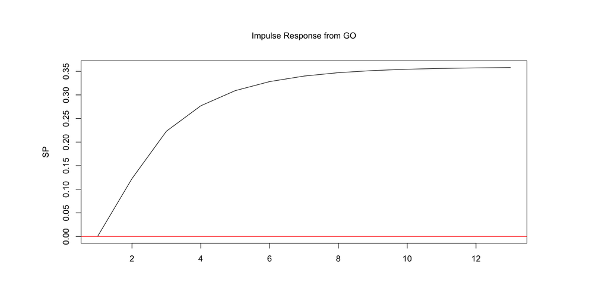

```r
#Analise das Funcoes Impulso Resposta

#Impulso em Goias e resposta em SP e MG
irfgosp <- irf(vec.level, impulse='GO', response='SP',
              boot = F, n.ahead=12, cumulative = F, ortho=F)
plot(irfgosp)
```

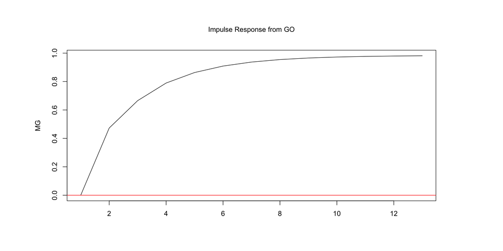

```r
irfgomg <- irf(vec.level, impulse='GO', response='MG',
               boot = F, n.ahead=12, cumulative = F, ortho=F)
plot(irfgomg)
```

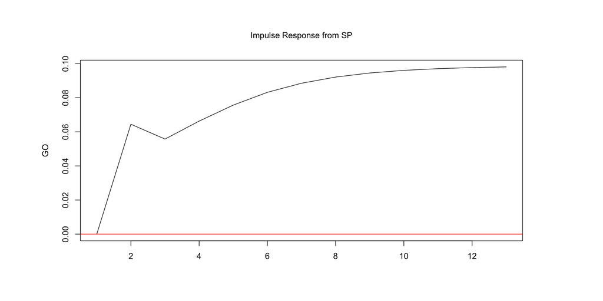

```r
#Impulso em Sao Paulo e resposta em Goias
irfspgo <- irf(vec.level, impulse='SP', response='GO',
               boot = F, n.ahead=12, cumulative = F, ortho=F)
plot(irfspgo)
```

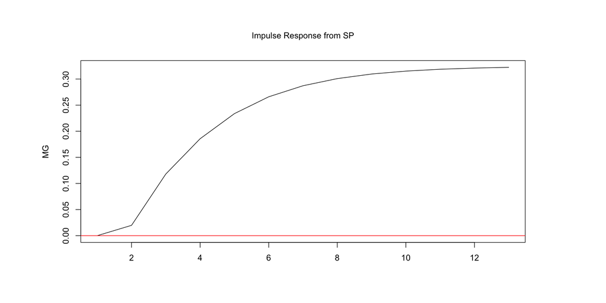

```r
irfspmg <- irf(vec.level, impulse='SP', response='MG',
               boot = F, n.ahead=12, cumulative = F, ortho=F)
plot(irfspmg)
```

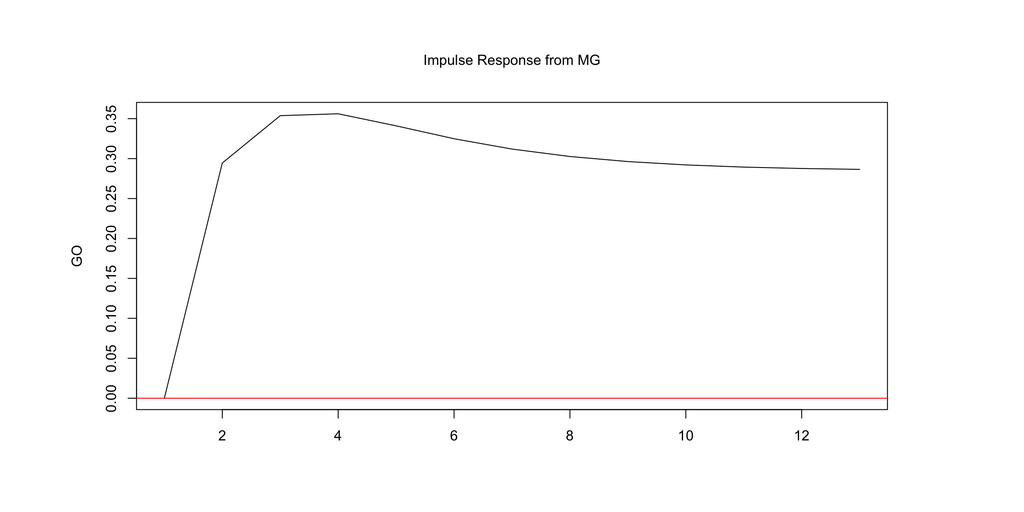

```r
#Impulso em Minas Gerais e resposta em Goias e S?o Paulo
irfmggo <- irf(vec.level, impulse='MG', response='GO',
               boot = F, n.ahead=12, cumulative = F, ortho=F)
plot(irfmggo)
```

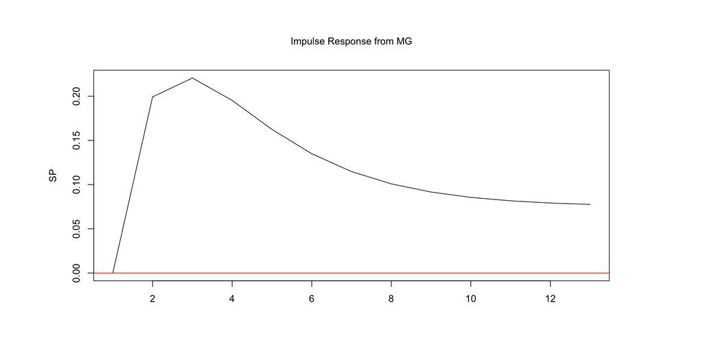

```r
irfmgsp <- irf(vec.level, impulse='MG', response='SP',
               boot = F, n.ahead=12, cumulative = F, ortho=F)
plot(irfmgsp)
```

## Decomposição da Variância da Previsão (FEVD)

```r
#Decomposicao da Variancia
fevd(vec.level, n.ahead=12)
```

```
$GO
             GO          SP         MG
 [1,] 1.0000000 0.000000000 0.00000000
 [2,] 0.9455013 0.009022565 0.04547613
 [3,] 0.9249226 0.011153853 0.06392356
 [4,] 0.9174026 0.012309661 0.07028772
 [5,] 0.9154365 0.012997823 0.07156569
 [6,] 0.9156552 0.013456157 0.07088862
 [7,] 0.9166736 0.013781602 0.06954482
 [8,] 0.9179138 0.014023781 0.06806245
 [9,] 0.9191407 0.014210465 0.06664879
[10,] 0.9202667 0.014358427 0.06537492
[11,] 0.9212670 0.014478367 0.06425467
[12,] 0.9221435 0.014577422 0.06327904

```

[output cut: 29 more lines]

A decomposição da variância foi feita para 12 passos à frente (12 períodos). Abaixo, a análise para cada variável:

### Variável GO (Goiás)

- Inicialmente, 100% da variância da previsão de GO é explicada por choques nela mesma.
- Após 12 períodos, 92,2% da variância ainda é explicada por GO, enquanto MG passa a contribuir com 6,3% e SP com apenas 1,5%.
- **Conclusão:** GO é fortemente autocentrada, com pouca influência das outras variáveis.

### Variável SP (São Paulo)

- No curto prazo, SP é majoritariamente explicada por choques nela mesma (73,9%).
- Ao longo do tempo, a influência de GO cresce, chegando a explicar 45% da variância da previsão de SP.
- MG tem pouca ou nenhuma influência.
- **Conclusão:** SP é relativamente autônoma, mas tem alguma dependência de GO no longo prazo.

### Variável MG (Minas Gerais)

- Inicialmente, 79,4% da variância de MG é explicada por ela mesma.
- Ao final do horizonte de previsão, apenas 21% continuam sendo explicados por MG, enquanto GO passa a explicar 72,4%.
- **Conclusão:** MG é fortemente influenciada por GO, sendo a variável mais reativa do sistema.

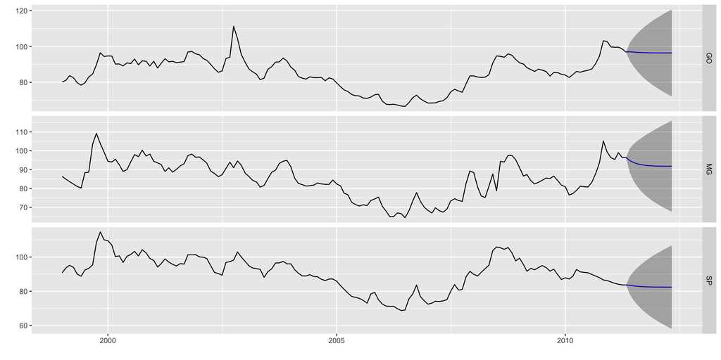

```r
#Previsão

vec.forecast <- predict(vec.level, n.ahead=12)

autoplot(vec.forecast)
```